# Datos y posibles barreras contextuales de mujeres que acuden al servicio de Interrupción Legal del Embarazo CDMX 2016 – 2020

Jennifer Lily Gamoneda Martínez

8/3/2021

En la Ciudad de México la interrupción del embarazo es legal hasta las 12 semanas de gestación, se realiza de forma segura y confidencial, independientemente de las razones por las cuales se requiera este servicio (ANDAR, 2020). Se estima que desde su legalización se han atendido aproximadamente a 213 mil 350 usuarias en esta entidad (CONAMED, 2019).

*Gráfico 1. Edad*

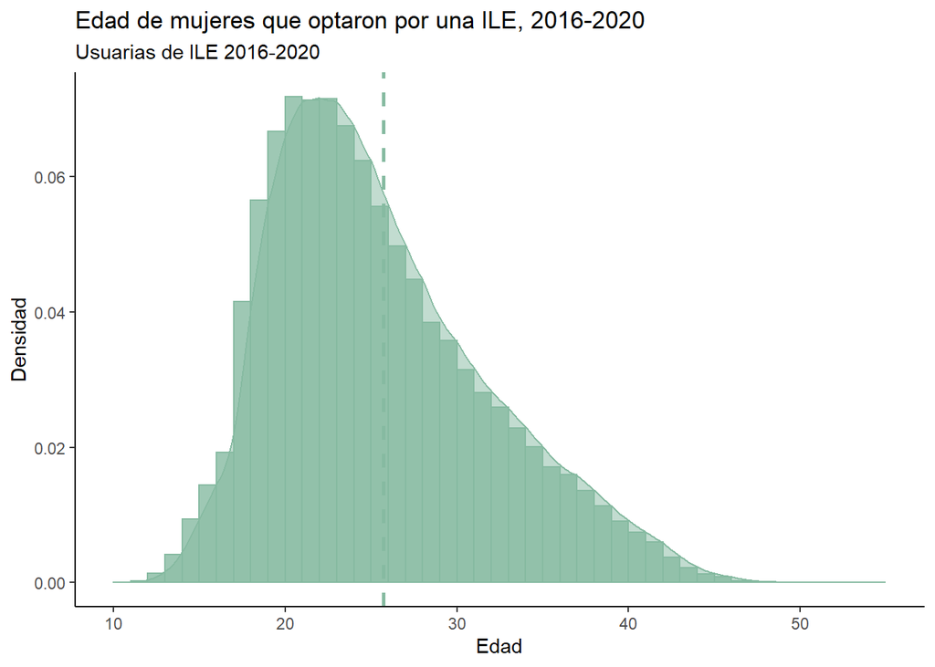

*Gráfico 2. Nivel educativo*

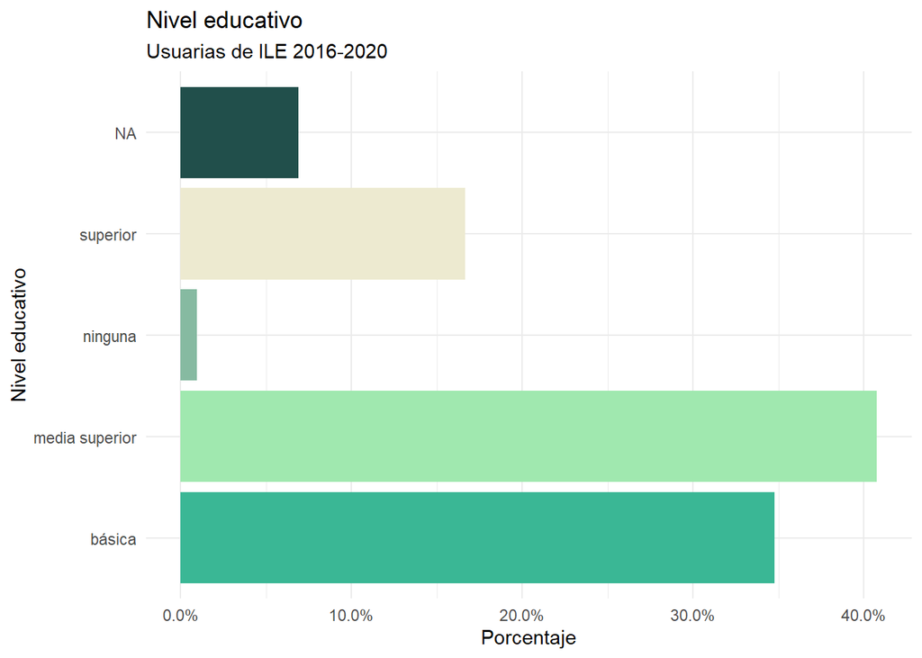

*Gráfico. 3 Ocupación*

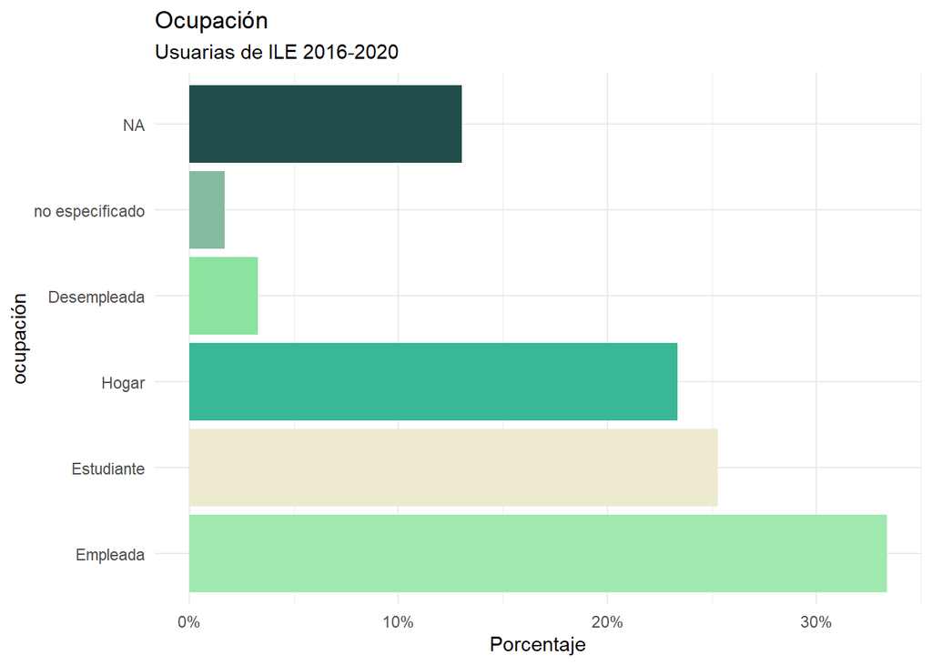

*Gráfico 4. Estado civil*

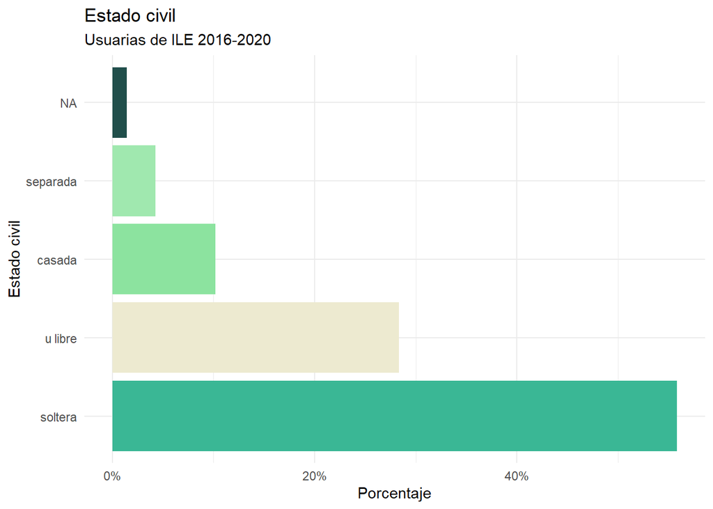

### Interpretación

La edad mediana de las mujeres coincide con otros estudios realizados en la Ciudad de México y en otros países (Sedgh, Bankole, Singh, y Eilers, 2013; Bernal-Becerril, Hernández-Ruiz, Mercader-Arroyo, Guerrero-Labastida, y Ponce-Gómez, 2010; CONAMED, 2019), sin embargo, a pesar de la densidad en edades jóvenes la ILE es un servicio obstétrico que se puede requerir a cualquier edad. Iniciando con aquellas que están entrando a la adolescencia (OMS, 2015) y que no se esperaría que requieran de este servicio, considerando que la edad promedio de inicio de vida sexual es a los 17 años (ENADID, 2018). Sin embargo, el Código Penal Federal, permite la interrupción legal del embarazo en todo el país por causal violación (art.333).

Aunado a esto, la Comisión Económica Para América Latina y el Caribe (2007) señala que las mujeres adolescentes son un grupo de mayor vulnerabilidad, ya que se espera que sean madres jóvenes, las cuales en ocasiones deben abandonar sus estudios (y no poder continuarlos), viven la necesidad de buscar un empleo y pueden enfrentar el abandono de su pareja.

Así como también, se debe indagar el comportamiento anticonceptivo dentro de las relaciones de pareja ya que la responsabilidad para prevenir un embarazo es tarea de mujeres y hombres, sin embargo, en estudios realizados en América Latina se ha encontrado que los hombres suelen relegar esta responsabilidad ya que lo consideran “un tema de mujeres” (Bonino, 2002); la prevención de un embarazo y el acompañamiento en la decisión de abortar depende del vínculo que mantiene el hombre con su pareja ya que cuando se tiene una relación formal o la aman mucho suele existir mayor responsabilidad a diferencia de aquellas con quienes no tienen una relación formal o no las aman (Lerner y Guillaume, 2008). Finalmente, de acuerdo con Clark, Allen, Goyal, Raker y Gottlieb (2014). es más probable que las mujeres que no tienen pareja o no saben el estado de su relación sufran coerción reproductiva.

Por lo tanto, se puede hipotetizar que las mujeres pueden presentar barreras para tener una educación sexual integral, que brinde información para prevenir un embarazo no esperado, prevenir el abuso sexual y reforzar habilidades para la asertividad sexual en las relaciones sexuales. Así como también, debe existir un compromiso institucional para que los varones también se involucren en la prevención de conductas sexuales de riesgo, eliminen la violencia hacia las mujeres.

```
Nota:
Se esperaría que las bases de datos libres tuvieran registros completos,
sin una gran cantidad de no registros (NA), ya que la información pérdida
resulta valiosa para a partir de ella analizar las situaciones, generar
nuevos estudios y proponer soluciones.
```

# ¿Te interesan los temas de salud sexual y reproductiva?

## Sigue a Resginfícame Esta!

### ¡Contáctanos!

Facebook: Resignifícame Esta. | Facebook https://www.facebook.com/resignificame

Instagram: Resignifícame ¡Esta! (@resignificameesta) • Fotos y videos de Instagram https://www.instagram.com/resignificameesta/

Twitter: Resignificame ¡Esta! (@resignificame) / Twitter https://twitter.com/resignificame

**Referencias**

Alianza Nacional por el Derecho a Decidir. (2020, 9 octubre). El aborto es legal en México -¡La ley te protege! Andar.org. https://andar.org.mx/aborto-legal/#CIUDADDEMEXICO

Bernal-Becerril, M. L., Hernández-Ruiz, Y. Y., Mercader-Arroyo, M. F., Guerrero-Labastida, A. T., & Ponce-Gómez, G. (2010). Caracterización de la población usuaria que ingresa al programa interrupción legal del embarazo en un hospital del sector salud del D.F. Enfermería universitaria, 7(1), 8-15.

Bonino, L. (2002) Masculinidad, salud y sistema sanitario en “Seminario sobre Mainstreaming de género en las políticas de salud en Europa”. Instituto de la mujer-España/OMS, y actualizado en Ruiz Jarabo C. y Blanco, P (Comp) (2004) La violencia contra las mujeres. Prevención y detección. Madrid: Diaz de Santos.

Clark, L., Allen, R., Goyal, V., Raker, C., & Gottlieb, A. (2014). Reproductive coercion and co-occurring intimate partner violence in obstetrics and gynecology patients. American Journal of Obstetrics & Gynecology, 210(1).

Código Penal Federal [CPF]. (2020, 20 octubre) Título Decimonoveno - Delitos contra la Vida y la Integridad Corporal. Capítulo VI - Aborto. Art.333. DOF 01-027-2020

Comisión Económica Para América Latina y el Caribe [CEPAL]. (2007). Maternidad adolescente en América Latina y el Caribe Tendencias, problemas y desafíos. Desafíos Boletín de la infancia y adolescencia sobre el avance de los objetivos de desarrollo del Milenio, 4, 5-11.

Comisión Nacional de Arbitraje Médico [CONAMED]. (2019, agosto). Boletín CONAMED Órgano de difusión del Centro Colaborador en Materia de Calidad de la Atención Médica y Seguridad del Paciente (No 25).

Encuesta Nacional de la Dinámica Demográfica [ENADID] (2018) Principales resultados. INEGI Consultado el 21 de agosto de 2020.

Lerner, S., y Guillaume, A. (2008). La participación de los varones en la práctica del aborto. Revista Latinoamericana de Población, 1(2), 29-45.

Organización Mundial de Salud. (2015, 1 diciembre). Desarrollo en la adolescencia. Organización Mundial de la Salud. https://www.who.int/maternal_child_adolescent/topics/adolescence/dev/es/

Santos-Iglesias, P., & Sierra, J. (2010). El papel de la asertividad sexual en la sexualidad humana: una revisión sistemática1. International Journal of Clinical and Health Psychology, 10(3).

Sedgh, G., Bankole, A., Singh, S., & Eilers, M. (2013). Legal Abortion Levels and Trends By Woman’s Age at Termination. Perspectives on Sexual and Reproductive Health, 45(1), 13-22.

Secretaría de Salud. (2020). Interrupción Legal del Embarazo (ILE). Secretarí¬a de Salud de la Ciudad de México. https://www.salud.cdmx.gob.mx/servicios/servicio/ILE